# R Notebook

For my classification dataset, I chose the Census Income dataset from the UCI Machine Learning Repository. The purpose of the dataset is to use attributes such as age, education level, and others to predict if a person’s income exceeds $50k/yr, with attributes collected from census data.

# Dataset

Let’s start by reading in the dataset and printing the number of rows and column names:

```r
# Read in the .csv file of the data set
df <- read.csv("CensusIncome.csv", header = TRUE)
# Print number of rows
print(paste("Number of rows:", nrow(df)))
```

```
## [1] "Number of rows: 32561"
```

```r
# Print attributes
names(df)
```

```
##  [1] "age"            "workclass"      "fnlwgt"         "education"
##  [5] "education.num"  "marital.status" "occupation"     "relationship"
##  [9] "race"           "sex"            "capital.gain"   "capital.loss"
## [13] "hours.per.week" "native.country" "income"
```

We see that the data set is large, with 32,561 rows and many columns, some being very ambiguously named.

# Data cleaning

Link to source: https://archive.ics.uci.edu/ml/datasets/Adult

Because the dataset is messy and needs cleaning, we will identify what predictors we want to use to predict our target column, being the “income” column.

The “fnlwgt” attribute has no documentation in the description of the dataset, so we want to remove it in case it is a non-predictive column that messes with our models in the future. We also want to deal with the “native.country” column, since there are many different countries a person can be from. Because the United States is likely the most common country, let’s see how many instances in the data-frame have the native-country of “United-States”:

```r
# Find number of instances of "United States"
numUS <- length(which(df$native.country == " United-States"))
print(paste("Number of instances with United States as native.country:", numUS))
```

```
## [1] "Number of instances with United States as native.country: 29170"
```

Because this is a large majority of our dataset, making it very imbalanced, we can remove this column altogether.Also, the “capital.loss” and “capital.gain” columns do not have description, and are both very ambiguous, which we also want to remove. Furthermore, the “marital.status” and “relationship” columns represent similar things, so we can remove “relationship” altogether. Lastly, the “education” and “education.num” column have the same data, but the “education.num” column assigns numerical values to the education level. Thus, we will remove the “education” column.

```r
df <- df[-c(3, 4, 8, 11, 12, 14)]
names(df)
```

```
## [1] "age"            "workclass"      "education.num"  "marital.status"
## [5] "occupation"     "race"           "sex"            "hours.per.week"
## [9] "income"
```

Let’s also check if there are any NA or NaN values in the columns of the dataset:

```r
colSums(is.na(df))
```

```
##            age      workclass  education.num marital.status     occupation
##              0              0              0              0              0
##           race            sex hours.per.week         income
##              0              0              0              0
```

Luckily we have no NA or NaN values, so we can proceed without having to replace anything with the mean of the column.

Lastly, let’s factorize some of our discrete, categorical predictors that are currently characters.

```r
df$workclass <- as.factor(df$workclass)
df$marital.status <- as.factor(df$marital.status)
df$occupation <- as.factor(df$occupation)
df$race <- as.factor(df$race)
df$sex <- as.factor(df$sex)
df$income <- as.factor(df$income)
```

# Data exploration

## R functions

Let’s use some R functions for data exploration.

```r
# Print the first 6 rows
head(df)
```

|  | age | workclass | education.num | marital.status | occupation | race | sex | hours.per.week | income |
| --- | --- | --- | --- | --- | --- | --- | --- | --- | --- |
| 1 | 39 | State-gov | 13 | Never-married | Adm-clerical | White | Male | 40 | <=50K |
| 2 | 50 | Self-emp-not-inc | 13 | Married-civ-spouse | Exec-managerial | White | Male | 13 | <=50K |
| 3 | 38 | Private | 9 | Divorced | Handlers-cleaners | White | Male | 40 | <=50K |
| 4 | 53 | Private | 7 | Married-civ-spouse | Handlers-cleaners | Black | Male | 40 | <=50K |
| 5 | 28 | Private | 13 | Married-civ-spouse | Prof-specialty | Black | Female | 40 | <=50K |
| 6 | 37 | Private | 14 | Married-civ-spouse | Exec-managerial | White | Female | 40 | <=50K |

```r
# Display the internal structure of the data frame
str(df)
```

```
## 'data.frame':    32561 obs. of  9 variables:
##  $ age           : int  39 50 38 53 28 37 49 52 31 42 ...
##  $ workclass     : Factor w/ 9 levels " ?"," Federal-gov",..: 8 7 5 5 5 5 5 7 5 5 ...
##  $ education.num : int  13 13 9 7 13 14 5 9 14 13 ...
##  $ marital.status: Factor w/ 7 levels " Divorced"," Married-AF-spouse",..: 5 3 1 3 3 3 4 3 5 3 ...
##  $ occupation    : Factor w/ 15 levels " ?"," Adm-clerical",..: 2 5 7 7 11 5 9 5 11 5 ...
##  $ race          : Factor w/ 5 levels " Amer-Indian-Eskimo",..: 5 5 5 3 3 5 3 5 5 5 ...
##  $ sex           : Factor w/ 2 levels " Female"," Male": 2 2 2 2 1 1 1 2 1 2 ...
##  $ hours.per.week: int  40 13 40 40 40 40 16 45 50 40 ...
##  $ income        : Factor w/ 2 levels " <=50K"," >50K": 1 1 1 1 1 1 1 2 2 2 ...
```

```r
# Print summary of dataset
summary(df)
```

```
##       age                    workclass     education.num
##  Min.   :17.00    Private         :22696   Min.   : 1.00
##  1st Qu.:28.00    Self-emp-not-inc: 2541   1st Qu.: 9.00
##  Median :37.00    Local-gov       : 2093   Median :10.00
##  Mean   :38.58    ?               : 1836   Mean   :10.08
##  3rd Qu.:48.00    State-gov       : 1298   3rd Qu.:12.00
##  Max.   :90.00    Self-emp-inc    : 1116   Max.   :16.00
##                  (Other)          :  981
##                 marital.status             occupation
##   Divorced             : 4443    Prof-specialty :4140
##   Married-AF-spouse    :   23    Craft-repair   :4099
##   Married-civ-spouse   :14976    Exec-managerial:4066
##   Married-spouse-absent:  418    Adm-clerical   :3770
##   Never-married        :10683    Sales          :3650
##   Separated            : 1025    Other-service  :3295
##   Widowed              :  993   (Other)         :9541
##                   race            sex        hours.per.week     income
##   Amer-Indian-Eskimo:  311    Female:10771   Min.   : 1.00    <=50K:24720
##   Asian-Pac-Islander: 1039    Male  :21790   1st Qu.:40.00    >50K : 7841
##   Black             : 3124                   Median :40.00
##   Other             :  271                   Mean   :40.44
##   White             :27816                   3rd Qu.:45.00
##                                              Max.   :99.00
##
```

```r
# Print the average age
print(paste("Average age:", mean(df$age)))
```

```
## [1] "Average age: 38.5816467553208"
```

```r
# Print the average education level
print(paste("Average education level:", mean(df$education.num)))
```

```
## [1] "Average education level: 10.0806793403151"
```

Although the education.num average doesn’t mean much by itself, we know from the description of the data set that 10.081 is approximately some-college education.

## R graphs

Now let’s create some informative R graphs for data exploration.

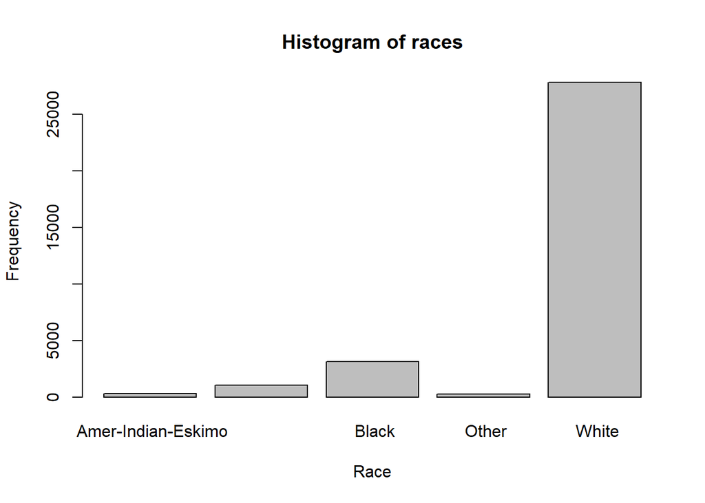

```r
# Histogram of race
barplot(table(df$race), main = "Histogram of races", xlab = "Race", ylab = "Frequency")
```

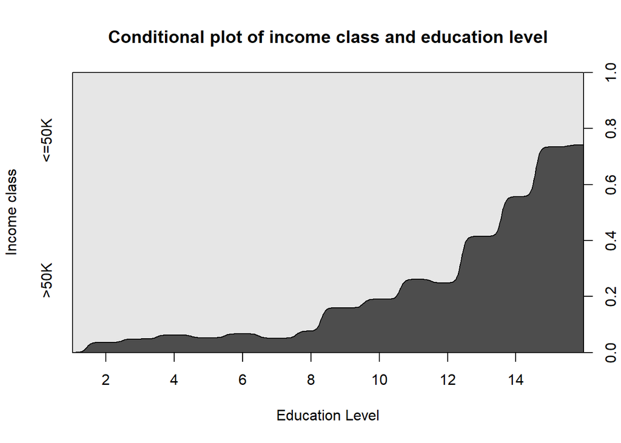

```r
# Conditional plot of education level and income
cdplot(df$education.num, df$income, main = "Conditional plot of income class and education level", xlab = "Education Level", ylab = "Income class")
```

Based on the graphs, we can see a much higher frequency of the the rows are White, followed by Black. This imbalance may prove to be an issue when building the models. Furthermore, as I thought, there is a clear correlation between education level and income.

# ML algorithms

We will attempt to run 3 classification algorithms over this dataset - Logistic Regression, Naive Bayes, and Decision Tree classification. Before running each algorithm, let’s discuss feature selection.

## Feature selection

The features in the dataset that are used to determine whether or not a person has an income above or below $50K are age, workclass, education.num, marital.status, occupation, race, sex, and hours.per.week. The reasons for eliminating other attributes was discussed in the data cleaning section above. We will now be discussing why these features were selected. Logically, hours worked per week, occupation, and workclass would likely have some correlation with income. These attributes deal directly with the amount someone works as well as their specialization of work, such which involves the occupation they work in as well as the specific workclass that occupation falls under. Education level similarly deals with how educated a person is, which would determine how skilled they are. Skilled labor obviously entails a higher income than unskilled labor, so this would also likely be an significant feature. Age somewhat coincides with the same reasons as education level, as work experience will come with age and will usually increase job prospects and therefore income. Marital status is important in many countries, as you are usually taxed based on your marital status. Lastly, race and sex can help us explore the softer side of some factors that can affect income. This involves gender and racial inequality with things such as wage gaps between people.

We can now start implementing our classification algorithms. Let’s begin by splitting our data into train and test sets of 75% and 25% respectively.

```r
# Set seed to ensure the same split of training and testing sets
set.seed(1234)
# Split the data
i <- sample(1:nrow(df), nrow(df) * 0.75, replace = FALSE)
train <- df[i, ]
test <- df[-i, ]
```

## Code to run logistic regression

Now we can run logistic regression over our predictors.

```r
# Run logistic regression
glm1 <- glm(income~., data = train, family = "binomial")
# Print summary of model
summary(glm1)
```

```
##
## Call:
## glm(formula = income ~ ., family = "binomial", data = train)
##
## Deviance Residuals:
##     Min       1Q   Median       3Q      Max
## -2.7532  -0.5528  -0.2348  -0.0541   3.1731
##
## Coefficients: (1 not defined because of singularities)
##                                        Estimate Std. Error z value Pr(>|z|)
## (Intercept)                           -9.457346   0.314669 -30.055  < 2e-16 ***
## age                                    0.029958   0.001740  17.220  < 2e-16 ***
## workclass Federal-gov                  1.077993   0.166447   6.476 9.39e-11 ***
## workclass Local-gov                    0.453074   0.151695   2.987  0.00282 **
## workclass Never-worked                -9.400845 182.267610  -0.052  0.95887
## workclass Private                      0.626070   0.135449   4.622 3.80e-06 ***
## workclass Self-emp-inc                 0.890491   0.161521   5.513 3.52e-08 ***
## workclass Self-emp-not-inc             0.158024   0.148603   1.063  0.28761
## workclass State-gov                    0.283525   0.164594   1.723  0.08497 .
## workclass Without-pay                -10.795833 149.978045  -0.072  0.94262
## education.num                          0.300996   0.009971  30.186  < 2e-16 ***
## marital.status Married-AF-spouse       2.492349   0.515665   4.833 1.34e-06 ***
## marital.status Married-civ-spouse      2.043124   0.069676  29.323  < 2e-16 ***
## marital.status Married-spouse-absent  -0.115808   0.233207  -0.497  0.61948
## marital.status Never-married          -0.520874   0.086331  -6.033 1.60e-09 ***
## marital.status Separated              -0.148791   0.171029  -0.870  0.38431
## marital.status Widowed                -0.102381   0.159964  -0.640  0.52216
## occupation Adm-clerical                0.105038   0.107270   0.979  0.32748
## occupation Armed-Forces               -0.733913   1.298322  -0.565  0.57188
## occupation Craft-repair                0.130142   0.093553   1.391  0.16419
## occupation Exec-managerial             0.863079   0.095704   9.018  < 2e-16 ***
## occupation Farming-fishing            -1.080921   0.161635  -6.687 2.27e-11 ***
## occupation Handlers-cleaners          -0.766117   0.168021  -4.560 5.12e-06 ***
## occupation Machine-op-inspct          -0.199659   0.116469  -1.714  0.08648 .
## occupation Other-service              -0.847058   0.136311  -6.214 5.16e-10 ***
## occupation Priv-house-serv            -2.702046   1.189139  -2.272  0.02307 *
## occupation Prof-specialty              0.626076   0.101615   6.161 7.22e-10 ***
## occupation Protective-serv             0.617408   0.143888   4.291 1.78e-05 ***
## occupation Sales                       0.319656   0.098542   3.244  0.00118 **
## occupation Tech-support                0.655462   0.131878   4.970 6.69e-07 ***
## occupation Transport-moving                  NA         NA      NA       NA
## race Asian-Pac-Islander                0.395880   0.267497   1.480  0.13889
## race Black                             0.454757   0.255765   1.778  0.07540 .
## race Other                             0.041110   0.366858   0.112  0.91078
## race White                             0.508402   0.245404   2.072  0.03829 *
## sex Male                               0.125662   0.056023   2.243  0.02489 *
## hours.per.week                         0.030948   0.001763  17.549  < 2e-16 ***
## ---
## Signif. codes:  0 '***' 0.001 '**' 0.01 '*' 0.05 '.' 0.1 ' ' 1
##
## (Dispersion parameter for binomial family taken to be 1)
##
##     Null deviance: 26878  on 24419  degrees of freedom
## Residual deviance: 17298  on 24384  degrees of freedom
## AIC: 17370
##
## Number of Fisher Scoring iterations: 12
```

Now let’s test the model over the testing set.

```r
# Assign probabilities and predictions based on the model
probs1 <- predict(glm1, newdata = test, type = "response")
pred1 <- ifelse(probs1 > 0.5, ">50K", "<=50K")
# Print the confusion matrix of the predictions vs. the test set
table(pred1, test$income)
```

```
##
## pred1    <=50K  >50K
##   <=50K   5691   917
##   >50K     454  1079
```

Looking at the table, we see that we got 5691 true positives, 1079 true negatives, 917 false positives, and 454 false negatives.

## Logistic regression metrics

These predictions compute to be the following metrics:

```r
# Calculate and print the accuracy
acc1 <- (5691 + 1079) / (5691 + 1079 + 917 + 454)
print(paste("Accuracy:", acc1))
```

```
## [1] "Accuracy: 0.83159317037219"
```

```r
# Calculate and print the sensitivity
sensitivity1 <- (5691) / (5691 + 454)
print(paste("Sensitivity:", sensitivity1))
```

```
## [1] "Sensitivity: 0.926118795768918"
```

```r
# Calculate and print the specificity
specificity1 <- (1079) / (1079 + 917)
print(paste("Specificity:", specificity1))
```

```
## [1] "Specificity: 0.540581162324649"
```

We can also use an ROC curve and AUC value to observe the performance.

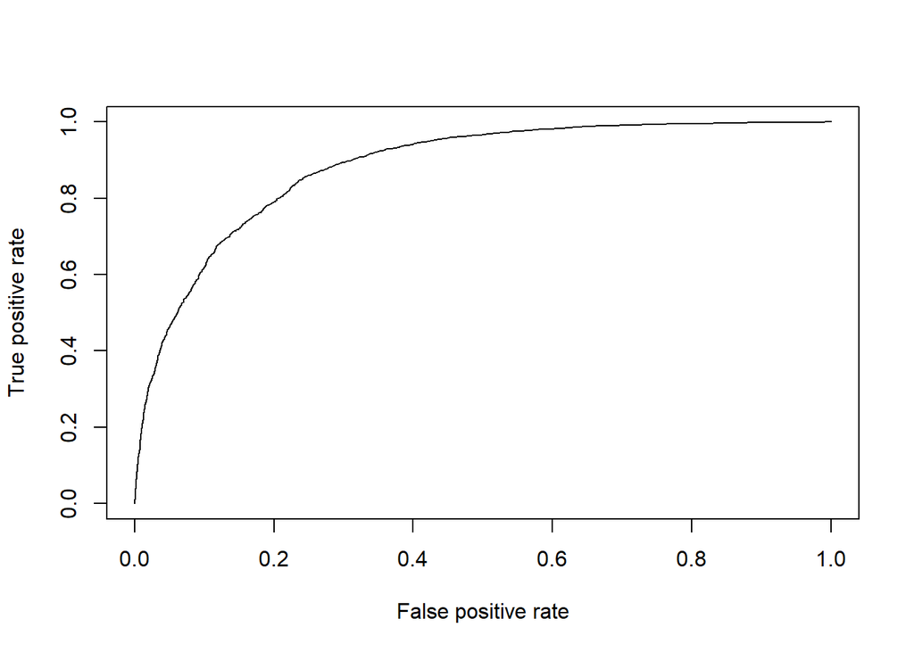

```r
# Plot the ROC curve
library(ROCR)
pr1 <- prediction(probs1, test$income)
prf1 <- performance(pr1, measure = "tpr", x.measure = "fpr")
plot(prf1)
```

```r
# Calculate and print the AUC value
auc1 <- performance(pr1, measure = "auc")
auc1 <- auc1@y.values[[1]]
print(paste("AUC:", auc1))
```

```
## [1] "AUC: 0.882468476415785"
```

We see that the ROC curve shoots upwards and to the right with a little space left on the top left. We also have a fairly high AUC value, which means our predictive value is decent.

## Code for Naive Bayes

Next we will try Naive Bayes using the same training and testing set from before so we get the most accurate comparison.

```r
library(e1071)
nb1 <- naiveBayes(income~., data = train)
summary(nb1)
```

```
##           Length Class  Mode
## apriori   2      table  numeric
## tables    8      -none- list
## levels    2      -none- character
## isnumeric 8      -none- logical
## call      4      -none- call
```

```r
nb1
```

```
##
## Naive Bayes Classifier for Discrete Predictors
##
## Call:
## naiveBayes.default(x = X, y = Y, laplace = laplace)
##
## A-priori probabilities:
## Y
##    <=50K     >50K
## 0.760647 0.239353
##
## Conditional probabilities:
##         age
## Y            [,1]     [,2]
##    <=50K 36.80861 14.06201
##    >50K  44.22618 10.43956
##
##         workclass
## Y                   ?  Federal-gov    Local-gov  Never-worked      Private
##    <=50K 0.0676177658 0.0231493943 0.0593808883  0.0003230148 0.7172005384
##    >50K  0.0244653550 0.0484174508 0.0802395210  0.0000000000 0.6337040205
##         workclass
## Y         Self-emp-inc  Self-emp-not-inc    State-gov  Without-pay
##    <=50K  0.0199730821      0.0743472409 0.0375235532 0.0004845222
##    >50K   0.0807527802      0.0881094953 0.0443113772 0.0000000000
##
##         education.num
## Y             [,1]     [,2]
##    <=50K  9.602584 2.454872
##    >50K  11.620701 2.350823
##
##         marital.status
## Y            Divorced  Married-AF-spouse  Married-civ-spouse
##    <=50K 0.1590847914       0.0005921938        0.3361507402
##    >50K  0.0612489307       0.0013686912        0.8544054748
##         marital.status
## Y         Married-spouse-absent  Never-married    Separated      Widowed
##    <=50K           0.0159892328   0.4140511440 0.0372543742 0.0368775236
##    >50K            0.0044482464   0.0602224123 0.0082121471 0.0100940975
##
```

[output cut: 20 more lines]

```
##    >50K          0.004106074         0.035072712 0.052181352 0.003592814
##         race
## Y              White
##    <=50K 0.837846568
##    >50K  0.905047049
##
##         sex
## Y           Female      Male
##    <=50K 0.3849798 0.6150202
##    >50K  0.1527802 0.8472198
##
##         hours.per.week
## Y            [,1]     [,2]
##    <=50K 38.84011 12.29228
##    >50K  45.44756 10.95034
```

Now let’s test the model over the testing set.

```r
pred2 <- predict(nb1, newdata = test, type = "class")
table(pred2, test$income)
```

```
##
## pred2     <=50K  >50K
##    <=50K   5362   683
##    >50K     783  1313
```

Looking at the table, we see that we got 5362 true positives, 1313 true negatives, 683 false positives, and 783 false negatives.

## Naive Bayes metrics

These predictions compute to be the following metrics:

```r
acc2 <- (5362 + 1313) / (5362 + 1313 + 683 + 783)
print(paste("Accuracy:", acc2))
```

```
## [1] "Accuracy: 0.819923842279818"
```

```r
# Calculate and print the sensitivity
sensitivity2 <- (5362) / (5362 + 783)
print(paste("Sensitivity:", sensitivity2))
```

```
## [1] "Sensitivity: 0.872579332790887"
```

```r
# Calculate and print the specificity
specificity2 <- (1313) / (1313 + 683)
print(paste("Specificity:", specificity2))
```

```
## [1] "Specificity: 0.657815631262525"
```

We can also use an ROC curve and AUC value to observe the performance.

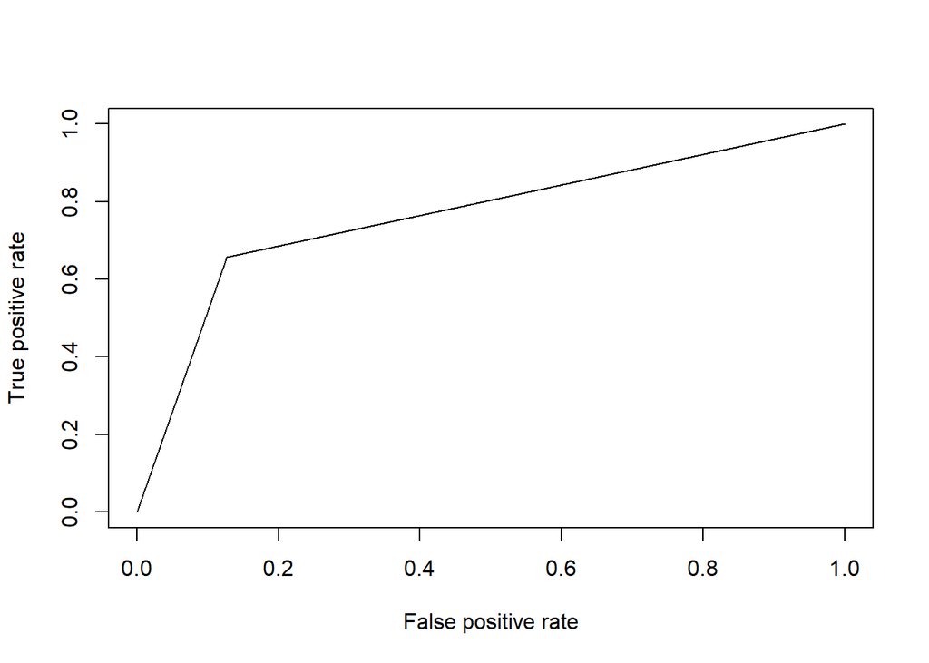

```r
# Plot the ROC curve
predvec1 <- ifelse(as.character(pred2) == " >50K", 1, 0)
realvec1 <- ifelse(as.character(test$income) == " >50K", 1, 0)
pr2 <- prediction(predvec1, realvec1)
prf2 <- performance(pr2, measure = "tpr", x.measure = "fpr")
plot(prf2)
```

```r
# Calculate and print the AUC value
auc2 <- performance(pr2, measure = "auc")
auc2 <- auc2@y.values[[1]]
print(paste("AUC:", auc2))
```

```
## [1] "AUC: 0.765197482026706"
```

We see that the ROC curve shoots upwards and to the right in a straighter with slightly more space left on the top left. We also have a fairly lower AUC value compared to that of logistic regression, which means our predictive value is not as good.

# Code for Decision Tree

Lastly, we will try Decision Tree classification once again using the same training and testing set from before so we get the most accurate comparison.

```r
# Run decision tree classification
library(tree)
```

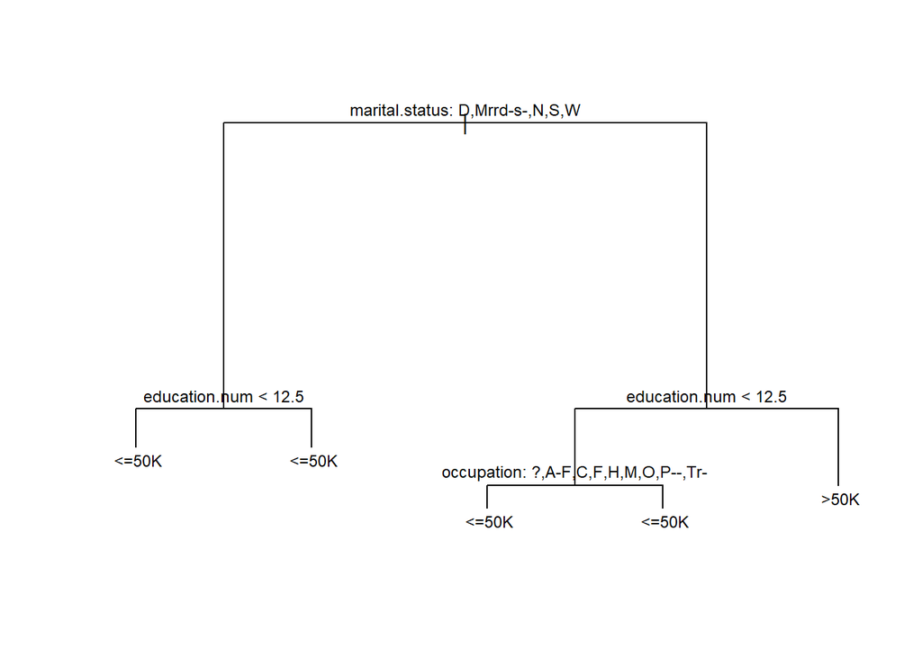

```r
tree1 <- tree(income~., data = train)
# Plot decision tree
plot(tree1)
text(tree1, cex = 0.75, pretty = 1)
```

Because our data is fairly complex, the actual decision tree diagram is fairly unclear and hard to read. Instead, we can try interpreting the decision tree outline:

```r
# Print decision tree outline
tree1
```

```
## node), split, n, deviance, yval, (yprob)
##       * denotes terminal node
##
##  1) root 24420 26880  <=50K ( 0.76065 0.23935 )
##    2) marital.status:  Divorced, Married-spouse-absent, Never-married, Separated, Widowed 13163  6264  <=50K ( 0.93596 0.06404 )
##      4) education.num < 12.5 10461  2951  <=50K ( 0.96817 0.03183 ) *
##      5) education.num > 12.5 2702  2618  <=50K ( 0.81125 0.18875 ) *
##    3) marital.status:  Married-AF-spouse, Married-civ-spouse 11257 15470  <=50K ( 0.55565 0.44435 )
##      6) education.num < 12.5 7863  9980  <=50K ( 0.66934 0.33066 )
##       12) occupation:  ?, Armed-Forces, Craft-repair, Farming-fishing, Handlers-cleaners, Machine-op-inspct, Other-service, Priv-house-serv, Transport-moving 4835  5383  <=50K ( 0.75512 0.24488 ) *
##       13) occupation:  Adm-clerical, Exec-managerial, Prof-specialty, Protective-serv, Sales, Tech-support 3028  4185  <=50K ( 0.53236 0.46764 ) *
##      7) education.num > 12.5 3394  4101  >50K ( 0.29228 0.70772 ) *
```

The output above is slightly unclear, so I copy-pasted it down below:

node), split, n, deviance, yval, (yprob) * denotes terminal node

1) root 24420 26880 <=50K ( 0.76065 0.23935 )  
2) marital.status: Divorced, Married-spouse-absent, Never-married, Separated, Widowed 13163 6264 <=50K ( 0.93596 0.06404 )  
4) education.num < 12.5 10461 2951 <=50K ( 0.96817 0.03183 ) *  
5) education.num > 12.5 2702 2618 <=50K ( 0.81125 0.18875 ) *  
3) marital.status: Married-AF-spouse, Married-civ-spouse 11257 15470 <=50K ( 0.55565 0.44435 )  
6) education.num < 12.5 7863 9980 <=50K ( 0.66934 0.33066 )  
12) occupation: ?, Armed-Forces, Craft-repair, Farming-fishing, Handlers-cleaners, Machine-op-inspct, Other-service, Priv-house-serv, Transport-moving 4835 5383 <=50K ( 0.75512 0.24488 ) *  
13) occupation: Adm-clerical, Exec-managerial, Prof-specialty, Protective-serv, Sales, Tech-support 3028 4185 <=50K ( 0.53236 0.46764 ) *  
7) education.num > 12.5 3394 4101 >50K ( 0.29228 0.70772 ) *

Let’s now test the model over the testing set.

```r
pred3 <- predict(tree1, newdata = test, type = "class")
table(pred3, test$income)
```

```
##
## pred3     <=50K  >50K
##    <=50K   5882  1180
##    >50K     263   816
```

Looking at the table, we see that we got 5882 true positives, 816 true negatives, 1180 false positives, and 263 false negatives.

## Decision Tree metrics

These predictions compute to be the following metrics:

```r
acc3 <- (5882 + 816) / (5882 + 816 + 1180 + 263)
print(paste("Accuracy:", acc3))
```

```
## [1] "Accuracy: 0.822749048028498"
```

```r
# Calculate and print the sensitivity
sensitivity3 <- (5882) / (5882 + 263)
print(paste("Sensitivity:", sensitivity3))
```

```
## [1] "Sensitivity: 0.95720097640358"
```

```r
# Calculate and print the specificity
specificity3 <- (816) / (816 + 1180)
print(paste("Specificity:", specificity3))
```

```
## [1] "Specificity: 0.408817635270541"
```

We can try pruning our tree to see if our performance improves:

```r
tree1_pruned <- prune.tree(tree1, best=5)
pred4 <- predict(tree1_pruned, newdata = test, type = "class")
table(pred4, test$income)
```

```
##
## pred4     <=50K  >50K
##    <=50K   5882  1180
##    >50K     263   816
```

This didn’t change our predictions at all, so we can continue analyzing the original tree.

We can use an ROC curve and AUC value to observe the performance.

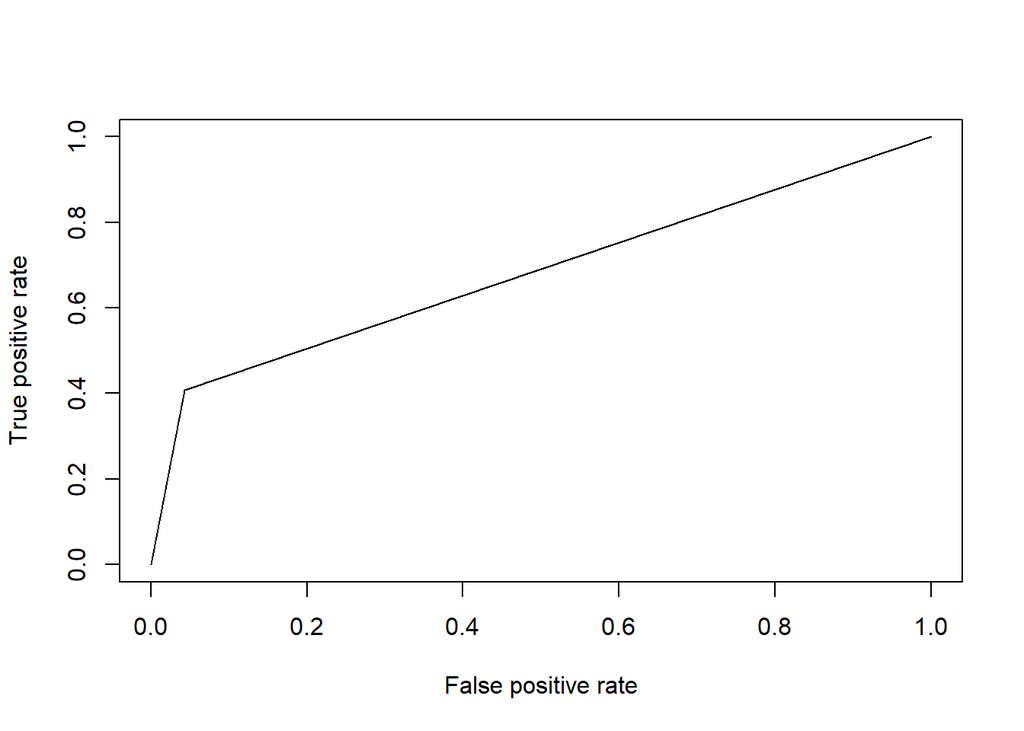

```r
# Plot the ROC curve
predvec2 <- ifelse(as.character(pred3) == " >50K", 1, 0)
realvec2 <- ifelse(as.character(test$income) == " >50K", 1, 0)
pr3 <- prediction(predvec2, realvec2)
prf3 <- performance(pr3, measure = "tpr", x.measure = "fpr")
plot(prf3)
```

```r
# Calculate and print the AUC value
auc3 <- performance(pr3, measure = "auc")
auc3 <- auc3@y.values[[1]]
print(paste("AUC:", auc3))
```

```
## [1] "AUC: 0.683009305837061"
```

We see that the ROC curve shoots upwards and to the right in a straighter with even more space left on the top left. We also have the lowest AUC value of all three models, which means our predictive value is the worst of the three.

# Results analysis

When analyzing the results of the algorithms, it is important to take into account all the metrics that we calculated earlier. These being accuracy, sensitivity, specificity, ROC curve, and AUC value.

## Performance and rankings

1. Logistic Regression
2. Naive Bayes
3. Decision Tree

## Why Logistic Regression was the best

Let’s compare logistic regression with the Naive Bayes and decision tree algorithms to see why it may have performed better in our data set.

### Logistic Regression vs. Naive Bayes

Logistic regression is a discriminative classifier, meaning that it directly estimates the parameters of P(Y|X). Naive Bayes is a generative classifier, meaning that it directly estimates parameters or P(Y) and P(X|Y). Naive Bayes also has the naive assumption, which assumes that each predictor is independent of each other. If this assumption holds true, which it generally doesn’t, then logistic regression and Naive Bayes over the same data set as the training set approaches infinity would converge towards very similar classifiers. In this dataset, we see some predictors that could be not independent, such as workclass and occupation. This would somewhat hurt the performance of Naive Bayes, which could suggest why it had worse performance than logistic regression. Furthermore, Naive Bayes will generally do better with smaller data sets, while logistic regression will improve in performance as the size of the data set increases. Because the size of our data set was so big, this could suggest why logistic regression performed better than Naive Bayes.